# Analysis of Cognitive Decline Related Indicators

Yuyao Zhang

2025-11-05

# Introduction

This analysis focuses on cognitive decline–related health indicators from the CDC Alzheimer’s Disease and Healthy Aging Data. We examine percentages of older adults reporting subjective cognitive decline (SCD) and its impacts, using data from 2015–2022 across U.S. states. Our objective is to summarize these indicators and visualize their trends over time.

The dataset includes survey-based indicators of subjective cognitive decline (SCD) among older adults. We focus on four specific survey questions directly measuring SCD and its consequences.

# Trend Over Time

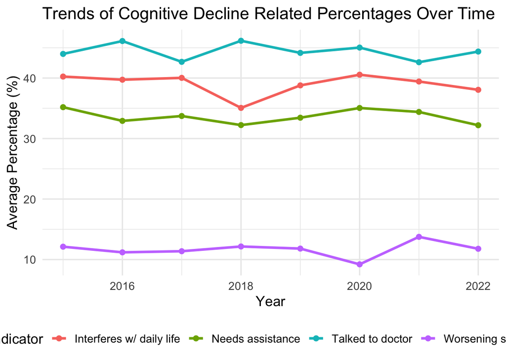

# Summary Table

Summary Statistics of Cognitive Decline Related Percentages

| Question_short | Mean_Percentage | SD_Percentage | Observations |
| --- | --- | --- | --- |
| Interferes w/ daily life | 39.19 | 13.52 | 5443 |
| Needs assistance | 33.75 | 12.49 | 5444 |
| Talked to doctor | 44.30 | 10.88 | 5441 |
| Worsening symptoms | 11.67 | 3.93 | 5854 |

The findings suggest that while a significant portion of older adults experience cognitive decline that impacts daily functioning, relatively few report worsening symptoms over time and less than half seek professional help. This highlights a potential gap in awareness, monitoring, and health care engagement. The table provides summary statistics across different cognitive decline–related survey questions. For instance, the mean percentages highlight differences in prevalence across questions.